# Logging and debugging in FaaSr

## Overview

When FaaSr functions execute in the cloud, errors may happen, and it is important that you add logging information so you can debug these errors. Because FaaS functions are stateless, FaaSr also use cloud S3 bucket storage to persist logging information.

## Configuring loggging folder in S3

By default, logs are stored in a folder named `FaaSrLog` in your configured S3 bucket. You can specify a different folder name in your JSON configuration file using the FaaSr JSON Builder, under the `General configuration` pull-down. Within this folder, for every execution of a workflow, a randomly-generated *UUID* (a long name that looks like `2f66208d-63eb-4fd9-b54b-7bebcc970421`) is created to store the logs for that workflow. The reason a *UUID* folder is created is to ensure that every FaaSr workflow execution has its own separate logs. In this way, you are able to safely run multiple workflows concurrently, and their logs are separate

## Logging from your code

To add a message to the log, use the `faasr_log()` function, with the following pattern as an example:

```
log_msg <- paste0('Function compute_sum finished; output written to ', folder, '/', output, ' in default S3 bucket')
faasr_log(log_msg)
```

## Checking the logs

Since logs are stored in S3, you may use any S3-compatible client to browse the logs. For example, using `minioclient`:

`mc_ls("play/faasr/FaaSrLog/")`

We’ll assume UUID `2f66208d-63eb-4fd9-b54b-7bebcc970421` in the examples below; please replace appropriately:

`mc_ls("play/faasr/FaaSrLog/2f66208d-63eb-4fd9-b54b-7bebcc970421/")`

Each action’s log is written as a file with the action’s name and extension `.txt`. For example, the log for `Action1` would be:

`mc_cat("play/faasr/FaaSrLog/2f66208d-63eb-4fd9-b54b-7bebcc970421/Action1.txt")`

## Locating specific UUID

To find out the specific *UUID* for a workflow run, you can check the FaaS-specific platform logs.

### GitHub Actions

You can go to the FaaSr-created Action repo, and click on the `Actions` tab, and expand the `run Rscript` link to see the `Action Invocation ID`, which matches the *UUID* for your logs:

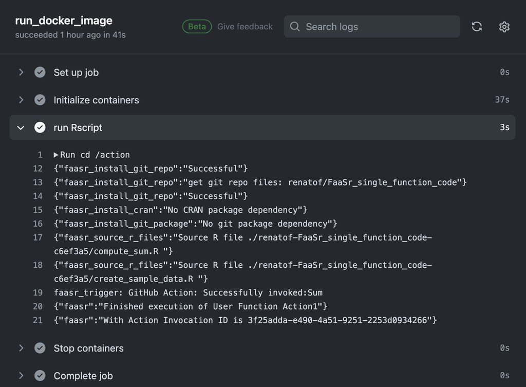

Locating UUID for logs, in GitHub Actions